# (Ford GoBike System Data)

## by (Fatema Buhuligah)

## Preliminary Wrangling

> This dataset includes information about individual rides made in a bike-sharing system covering the greater San Francisco Bay area.

### 1. user_type

**The number of trips of Subscriber users is more than the number of trips of Customer users. In which (less than 160,000 trips of the total) 90.53% of the trips taken by Subscriber type whereas (less than 20,000 trips of the total) 9.47% of the trips taken by the customer type.**

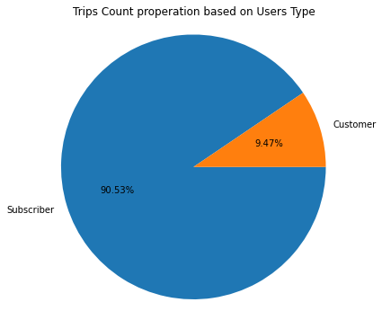

```python
plt.figure(figsize = [10, 6])
user = df_clean['user_type'].value_counts()
plt.pie(user, labels = user.index, counterclock = False, autopct='%1.2f%%')
plt.axis('square')
plt.title('Trips Count properation based on Users Type');
```

### 2. member_gender

**The gender with higher trip count is Male, with more than 120,000 trips. And then Female gender with approximately 40,000 trips then the Other gender.**

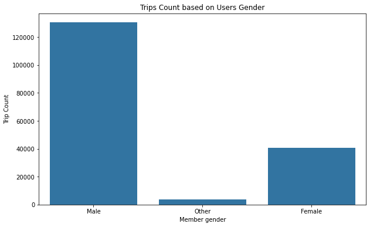

```python
plt.figure(figsize=[10, 6])
sb.countplot(data = df_clean, x ='member_gender', color = base_color)
plt.title('Trips Count based on Users Gender')
plt.xlabel('Member gender')
plt.ylabel('Trip Count');
```

### 3. member_age

**The most bike trips are for members between 25-35 years old , and the number of trips gradually decreases as the age increases.**

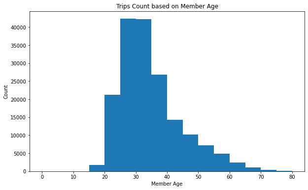

```python
bins = np.arange(0,df_clean['member_age'].max()+5,5)
plt.figure(figsize=[10, 6])
plt.hist(data = df_clean, x = 'member_age' , bins = bins)
plt.xlabel('Member Age')
plt.ylabel('Count')
plt.title('Trips Count based on Member Age');
```

### 4. bike_share_for_all_trip

**90.10% of the members are not sharing the bike for all trip, whereas the rest of members are sharing the bike for all the trip with a properation of 9.90%.**

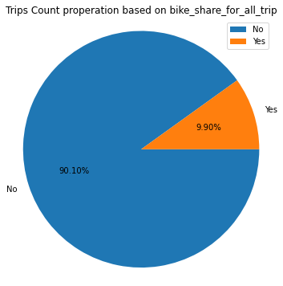

```python
plt.figure(figsize = [10, 6])
user = df_clean['bike_share_for_all_trip'].value_counts()
legend =  df_clean['bike_share_for_all_trip'].unique()
plt.pie(user, labels = user.index, counterclock = False, autopct='%1.2f%%')
plt.legend(legend)
plt.axis('square')
plt.title('Trips Count properation based on bike_share_for_all_trip');
```

### 5. Start_Day

**On weekend the users take the least trips of the week. It is less than 15,000 trips. Whereas on Thursday the users take the most trips.**

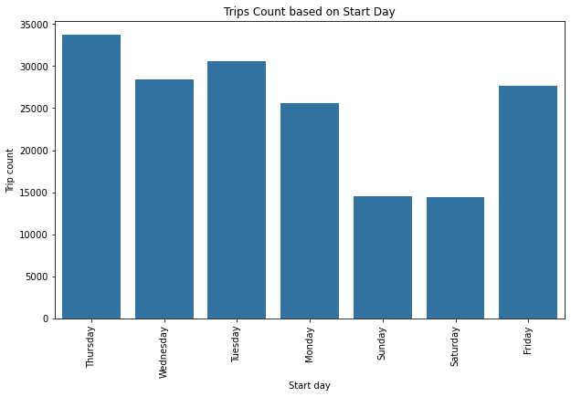

```python
plt.figure(figsize = [10, 6])
sb.countplot(data = df_clean, x ='start_Day', color = base_color)
plt.xticks(rotation=90)
plt.title('Trips Count based on Start Day')
plt.xlabel('Start day')
plt.ylabel('Trip count');
```

### 6. duration_min

**The majority of trips had duration of less than 1 hour, and most of them are between 2 to 12 range of minutes.**

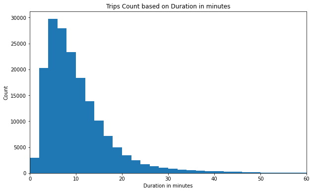

```python
bins = np.arange(0,df_clean['duration_min'].max(),2)
plt.figure(figsize=[10, 6])
plt.hist(data = df_clean, x = 'duration_min' , bins = bins)
plt.xlim((0 , 60))
plt.xlabel('Duration in minutes')
plt.ylabel('Count')
plt.title('Trips Count based on Duration in minutes');
```

### 1. duration_min vs. user_type

**The cutomer user type have longer trip duration in minutes than the subscriber type. It seems like the customer will rent the bike and use it instantaneously. Whereas subscribers feel they are not in a rush to use the bike since they already have the annual subscription.**

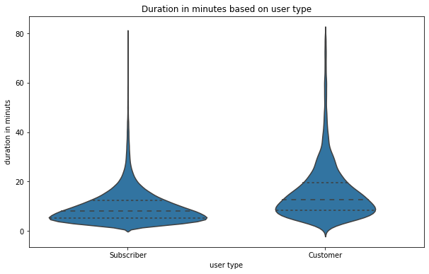

```python
plt.figure(figsize = [10, 6])
sb.violinplot(data=duration_df, x='user_type', y='duration_min', color=base_color, inner='quartile')
plt.title('Duration in minutes based on user type')
plt.xlabel('user type')
plt.ylabel('duration in minuts');
```

### 2. duration_min vs. member_age

**Trips taken by members with age above 65 are almost 60 minutes or less, whereas the members with age under 65 took more than an hour.**

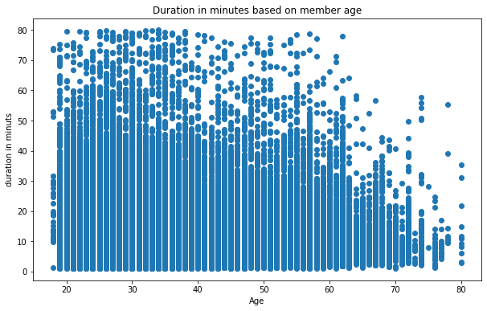

```python
plt.figure(figsize=[10, 6])
plt.scatter(data = duration_df,  x = 'member_age', y = 'duration_min');
plt.title('Duration in minutes based on member age')
plt.xlabel('Age')
plt.ylabel('duration in minuts');
```

### 3. duration_min vs. start_Day

**The duration of trips on weekends (Saturday & Sunday) are higher than the trips on the weekdays.**

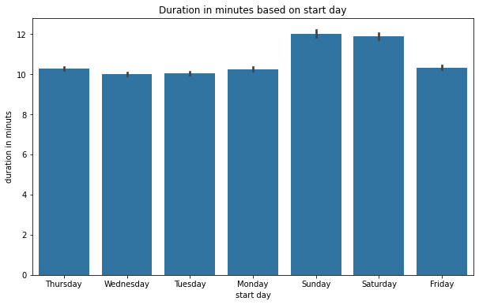

```python
plt.figure(figsize = [10, 6])
sb.barplot(data=duration_df, x='start_Day', y='duration_min', color=base_color)
plt.title('Duration in minutes based on start day')
plt.xlabel('start day')
plt.ylabel('duration in minuts');
```

### 4. user_type vs. bike_share_for_all_trip

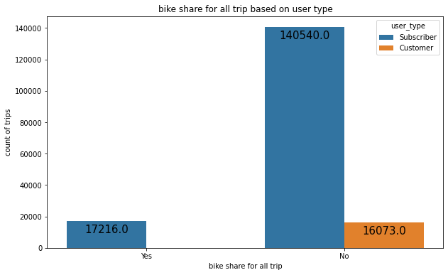

```python
plt.figure(figsize = [10, 6])

splot = sb.countplot(data = duration_df, x = 'bike_share_for_all_trip', hue = 'user_type')

for p in splot.patches:
    splot.annotate(format(p.get_height(), '.1f'),
                   (p.get_x() + p.get_width() / 2., p.get_height()),
                   ha = 'center', va = 'center',
                   size=15,
                   xytext = (0, -12),
                   textcoords = 'offset points')
plt.title('bike share for all trip based on user type')
plt.xlabel('bike share for all trip')
plt.ylabel('count of trips');
```

### 1. duration_min vs. start_Day based on user_type

**The average duration of trips for subscriber user type among the week days is the almost the same. Whereas the average duration of trips for customer user type among the week days is jumped to its highest on the weekends, and the rest of the week day it almost closely similar.**

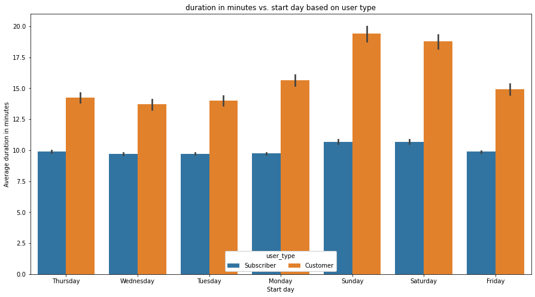

```python
plt.figure(figsize = [15, 8])
ax = sb.barplot(data = duration_df, x = 'start_Day', y = 'duration_min', hue = 'user_type')
ax.legend(loc = 8, ncol = 3, framealpha = 1, title = 'user_type')
plt.xlabel('Start day')
plt.ylabel('Average duration in minutes')
plt.title('duration in minutes vs. start day based on user type');
```

### 2. duration_min vs. start_Hour based on member_age

**The members under 60 years old are having the most trips all day long with variety of trip duration in minutes. Whereas members above 50 are having their most trips likely in the first hours of the day, in the early morning and the trip duration almost less than an hour (60 minutes).**

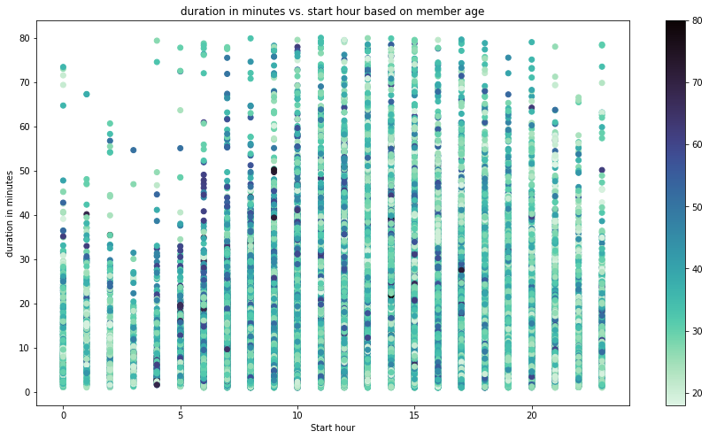

```python
plt.figure(figsize = [15, 8])
plt.scatter(data = duration_df, x = 'start_Hour', y = 'duration_min', c = 'member_age', cmap = 'mako_r')
plt.colorbar()
plt.title('duration in minutes vs. start hour based on member age')
plt.xlabel('Start hour')
plt.ylabel('duration in minutes');
```

```python
!jupyter nbconvert slide_deck_template.ipynb --to slides --post serve --template output_toggle
```

[output not shown]